# Mapletech Data Exploration

Karen Jiang

4/6/2020

## Strike a Deal!

Only one group in our class did not reach an agreement on a final price for this exercise.

Group 48, are you real data? Regardless, we’ll filter you out from the following analysis.

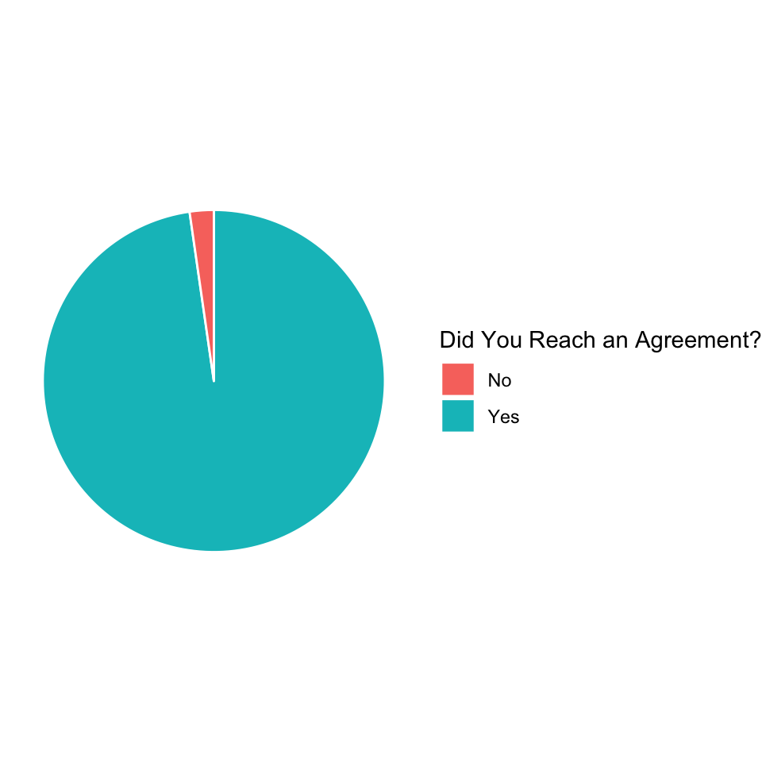

## BATNA and Who Goes First?

The **BATNA** is the *Best Alternative to a Negotiated Agreement*.

Mapletech’s BATNA would have been no deal (no gains, no losses). Yazawa’s BATNA on the other hand would have been to buy the same part from another manufacturer at $35 / unit.

Mapletech might have had the upper hand in this negotiation, but they also more frequently made the first offer.

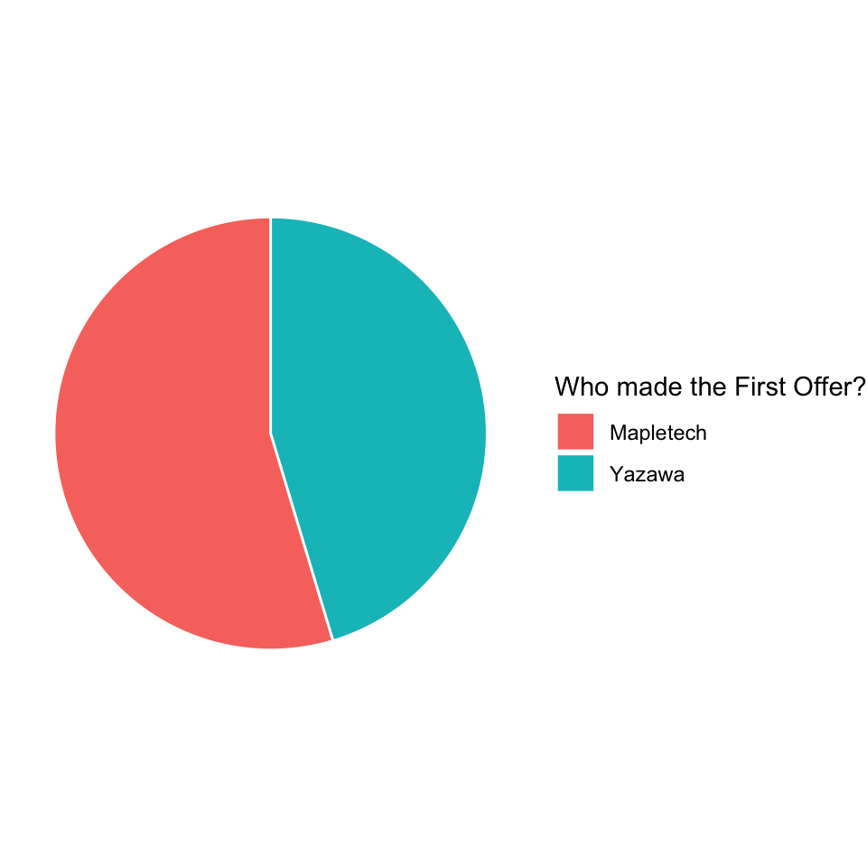

### Zone of Possible Agreement

Mapletech’s reservation point was $10. Yazawa’s reservation point was $35.

Any amount between that is the **Zone of Possible Agreement**, or **ZOPA**.

## Target Price

Target prices were generally anchored around the values provided by the case guidelines. However, there are a handful of folks in Mapletech who were less constrained by anchors, and chose even higher target prices.

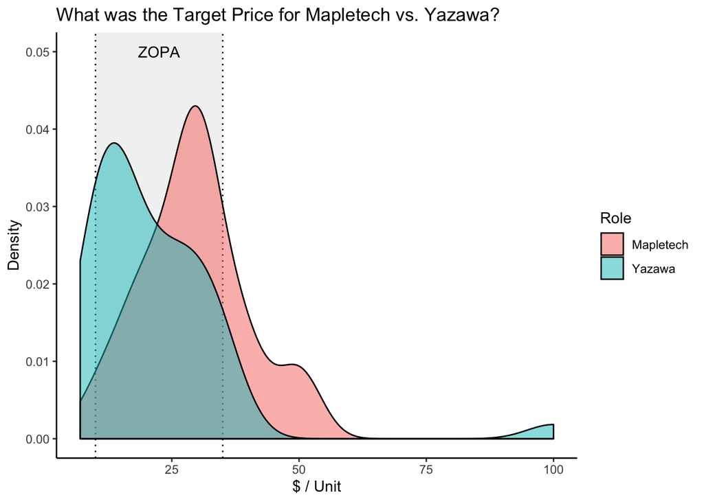

How does an internal, unstated target price affect the First Offer?

## First Offer

Yazawa’s first offers were near $10 range (Mapletech’s reservation point), right at the edge of the ZOPA, while Mapletech’s first offers were around $40, outside of the ZOPA.

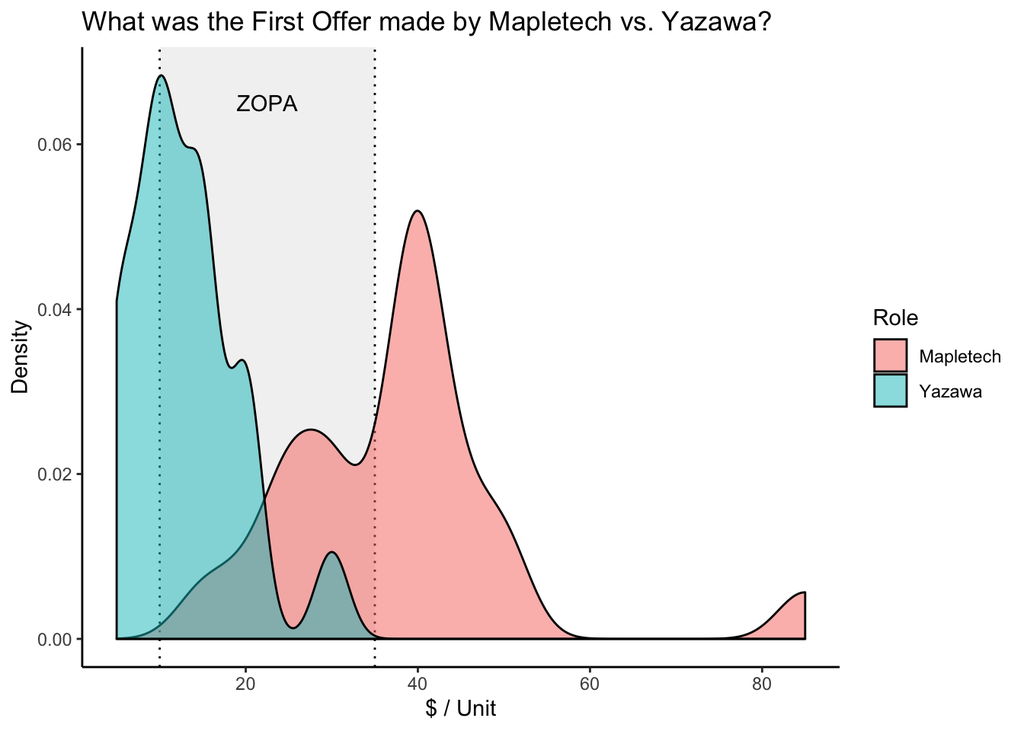

## Did making the First Offer make a difference?

The results are counter-intuitive.

We would have expected that if Mapletech made the first offer and set an high anchor, we would expect that a peak in the final price near the higher end of the ZOPA. Instead, we see a relatively uniform distribution between %15 and $30.

When Yazawa made the first offer, there is a bimodal distribution with peaks at $20 and $30, suggesting that Yazawa making the first offer was only effective in lowering the final agreed price for a few cases.

However almost all deals were reached within the ZOPA (as should be the case).

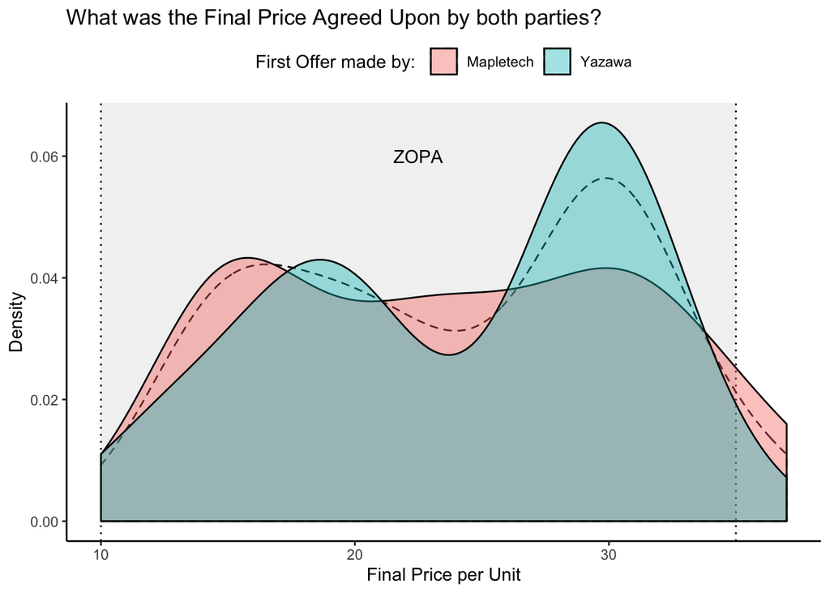

How might this result be explained by the negotiation process?

## The Negotiation

### First Offer and Counter Offer

First, let’s understand what’s happening with the visual:

- **Black Dots** represent the amount of the First Offer.
- Orange Dots represent the Counter Offer.
- The graph is split by who made the First Offer
  - Mapletech on the Left
  - Yazawa on the Right

Generally, when the first offer was an extreme low/high ball, they were met with an aggressive counter. The counter offer range tends to decrease if the first offer was closer to center of the ZOPA.

Group 37 represents a case of a very reasonable First Offer that was accepted immediately.

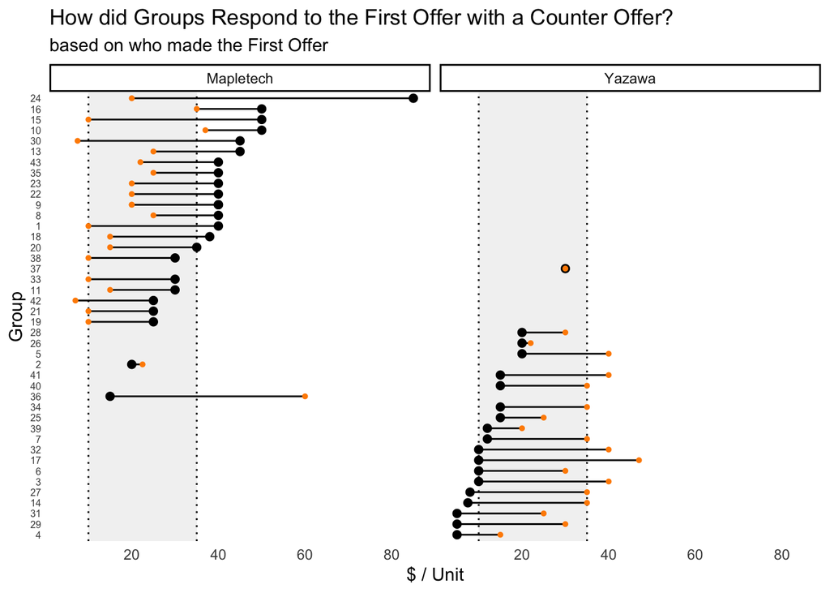

### Final Amount

Now we can add the Final amount to the graph, which is represented by a Blue X.

The final offers tend to split the difference between the First Offer and Counter Offer.

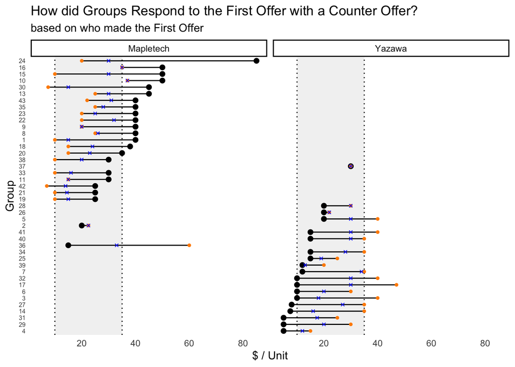

In certain cases, a good counter-offer can be just as effective in setting an achor as the First Offer.

[output not shown]